# Title: Assignment 2

Crim 250: Statistics for the Social Sciences Name: Aisha Njie Date: 09/27/2021

# Assignment 2

Problem 1: Load data

Set your working directory to the folder where you downloaded the data.

```r
setwd("/Users/isatounjie/Documents/GitHub/Aishas-Website/Assignment 2")
```

Read the data

```r
dat <- read.csv("dat.nsduh.small.1.csv")
```

What are the dimensions of the dataset?

```r
names(dat)
```

```
## [1] "mjage"     "cigage"    "iralcage"  "age2"      "sexatract" "speakengl"
## [7] "irsex"
```

Answer: The dimensions of the dataset are mjage, cigage, iralcage, age2, sexatract, speakengl, and irsex.

## Problem 2: Variables

```r
class(dat$mjage)
```

```
## [1] "integer"
```

```r
class(dat$cigage)
```

```
## [1] "integer"
```

```r
class(dat$iralcage)
```

```
## [1] "integer"
```

```r
class(dat$age2)
```

```
## [1] "integer"
```

```r
class(dat$sexatract)
```

```
## [1] "integer"
```

```r
class(dat$speakengl)
```

```
## [1] "integer"
```

```r
class(dat$irsex)
```

```
## [1] "integer"
```

Describe the variables in the dataset.

Answer: It appears that mjage, cigage, iralcage, age2, sexatract, and speakengl are all ordinal variables and irsex is a categorical variable. It could also be regarded as an ordinal variable. In terms of r type, they are all intergers.

What is this dataset about? Who collected the data, what kind of sample is it, and what was the purpose of generating the data?

Answer: This dataset observes the age at which participants first tried marijuana, first started smoking cigarettes every day,first tried alcohol, what they identify as in terms of gender, their sexual attraction, how well they speak English as well as the final recorded age of the participants. The data was collected from The National Survey on Drug Use and Health, specifically RTI International. Even though participants are selected and then interviewed, I believe this is an example of simple random sampling. Participants aren’t chosen just because they fit a certain criteria.

## Problem 3: Age and gender

What is the age distribution of the sample like? Make sure you read the codebook to know what the variable values mean.

Answer: Ranges 1-10 signify a participant at one, specific age, however ranges 11-12 signify an option between two ages, and ranges 13-16 signify a range of ages. 17 signifies the largest range with participants that are 65 or older.

Do you think this age distribution representative of the US population? Why or why not?

Answer: Yes, I believe this is representative of the US population in the context of this study. Children start experimenting (in terms of drugs, sex, and alcohol) around the age of 12. Also, it is unlikely to receive parental consent for a study like this for children that are too young.

*Correction: They cut off the survey at age 12 by design, not because they found people used drugs less below that age (although that is probably also true). There are other surveys of children’s use of drugs.

Is the sample balanced in terms of gender? If not, are there more females or males?

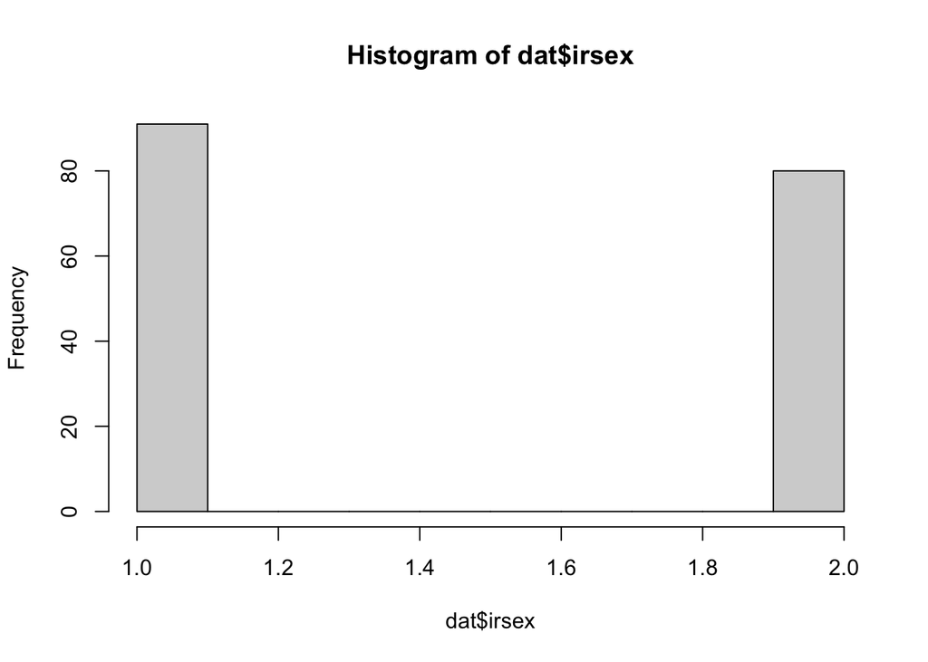

```r
hist(dat$irsex)
```

Answer: This sample is nearly balanced, there are 91 participants that identify as male and 80 that identify as female.

Use this code to draw a stacked bar plot to view the relationship between sex and age. What can you conclude from this plot?

```r
table(dat$irsex,dat$age2)
```

```
##
##      4  6  7  8  9 10 11 12 13 14 15 16 17
##   1  1  1  1  0  1  1  3  3 14 10 33 14  9
##   2  1  0  0  2  6  2  3  4 13  6 29 10  4
```

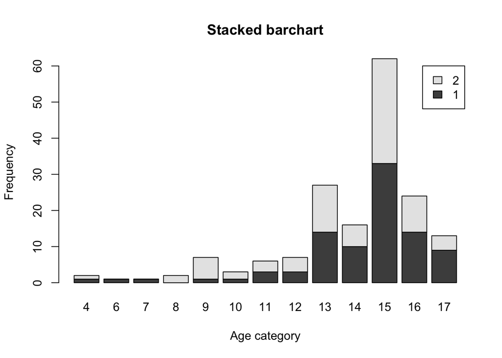

```r
tab.agesex <- table(dat$irsex,dat$age2)
barplot(tab.agesex,
        main = "Stacked barchart",
        xlab = "Age category", ylab = "Frequency",
        legend.text = rownames(tab.agesex),
        beside = FALSE) # Stacked bars (default)
```

Answer: In the youngest age group (4) and group 11, there is an even split. In age groups 6, 7, 13, 14, 15, 16, and 17 there are more men than female, however in age groups 8, 9,10, and 12 there are more females. Men dominate the majority of all the age groups.

## Problem 4: Substance use

*correction: table is not needed. just look at lowest value for all the different groups.

*why do the age values go past 17 for mjage, cigage, and iralcage.* barplots don’t actually help to see this, but I don’t know how to get a breakdown of the data points within each group.

For which of the three substances included in the dataset (marijuana, alcohol, and cigarettes) do individuals tend to use the substance earlier?

Individuals tend to use alcohol earliest.

```r
table(dat$mjage,dat$age2)
```

```
##
##      4 6 7 8 9 10 11 12 13 14 15 16 17
##   7  0 0 0 0 0  0  0  0  1  0  0  0  0
##   9  1 0 0 0 0  0  0  0  1  1  0  1  0
##   10 0 0 0 0 0  0  0  0  0  1  0  1  0
##   11 0 0 0 1 0  0  0  0  1  0  3  1  1
##   12 0 0 0 0 0  0  1  1  2  0  5  1  0
##   13 0 1 0 0 2  0  1  1  4  1  5  1  0
##   14 1 0 0 0 2  1  0  0  2  3  9  4  0
##   15 0 0 0 0 1  1  1  0  2  0  8  6  3
##   16 0 0 0 1 0  0  1  3  5  5  7  6  0
##   17 0 0 0 0 2  1  1  1  3  1  5  1  1
##   18 0 0 1 0 0  0  1  1  0  1  8  2  2
##   19 0 0 0 0 0  0  0  0  2  0  2  0  0
##   20 0 0 0 0 0  0  0  0  0  2  4  0  1
##   21 0 0 0 0 0  0  0  0  2  0  1  0  3
##   22 0 0 0 0 0  0  0  0  1  0  1  0  0
##   25 0 0 0 0 0  0  0  0  1  0  0  0  1
##   27 0 0 0 0 0  0  0  0  0  0  2  0  0
##   30 0 0 0 0 0  0  0  0  0  0  1  0  0
##   32 0 0 0 0 0  0  0  0  0  0  0  0  1
##   33 0 0 0 0 0  0  0  0  0  1  0  0  0
##   35 0 0 0 0 0  0  0  0  0  0  1  0  0
```

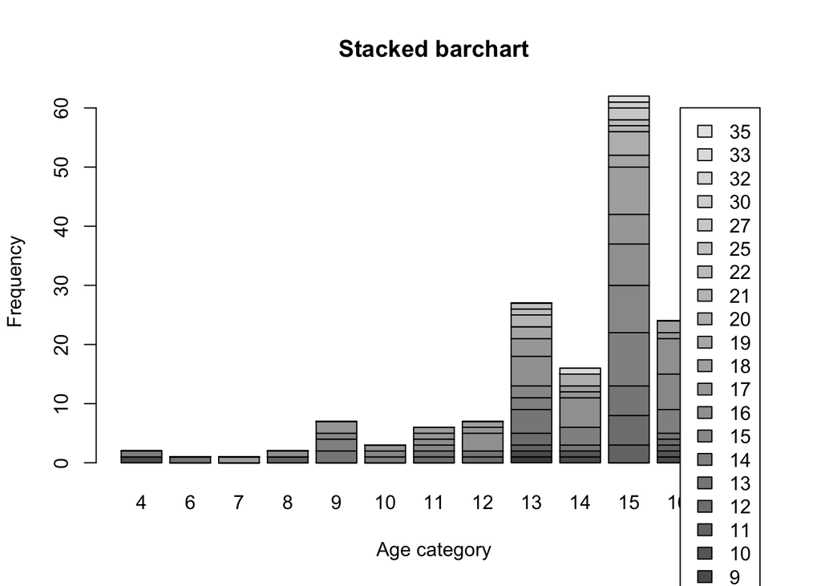

```r
tab.agemjage <- table(dat$mjage,dat$age2)
barplot(tab.agemjage,
        main = "Stacked barchart",
        xlab = "Age category", ylab = "Frequency",
        legend.text = rownames(tab.agemjage),
        beside = FALSE) # Stacked bars (default)
```

```r
table(dat$cigage,dat$age2)
```

```
##
##       4  6  7  8  9 10 11 12 13 14 15 16 17
##   10  0  0  0  0  0  0  0  0  0  0  1  0  0
##   11  0  0  0  0  0  0  0  0  0  0  0  0  1
##   12  0  0  0  0  0  0  0  1  1  0  0  1  0
##   13  1  0  0  0  0  0  0  0  0  0  5  3  1
##   14  1  0  1  0  1  0  0  1  2  0  3  1  0
##   15  0  1  0  0  2  0  1  0  6  0 10  4  1
##   16  0  0  0  0  0  1  1  0  4  3  8  7  1
##   17  0  0  0  2  2  1  0  1  4  3  2  2  3
##   18  0  0  0  0  2  1  3  2  4  4 12  2  1
##   19  0  0  0  0  0  0  0  2  2  1  6  0  0
##   20  0  0  0  0  0  0  1  0  2  0  4  2  1
##   21  0  0  0  0  0  0  0  0  1  1  4  0  0
##   22  0  0  0  0  0  0  0  0  0  1  3  0  1
##   23  0  0  0  0  0  0  0  0  0  2  1  1  0
##   24  0  0  0  0  0  0  0  0  1  0  0  0  0
##   25  0  0  0  0  0  0  0  0  0  1  1  0  2
##   27  0  0  0  0  0  0  0  0  0  0  1  0  0
##   35  0  0  0  0  0  0  0  0  0  0  1  0  0
##   45  0  0  0  0  0  0  0  0  0  0  0  0  1
##   50  0  0  0  0  0  0  0  0  0  0  0  1  0
```

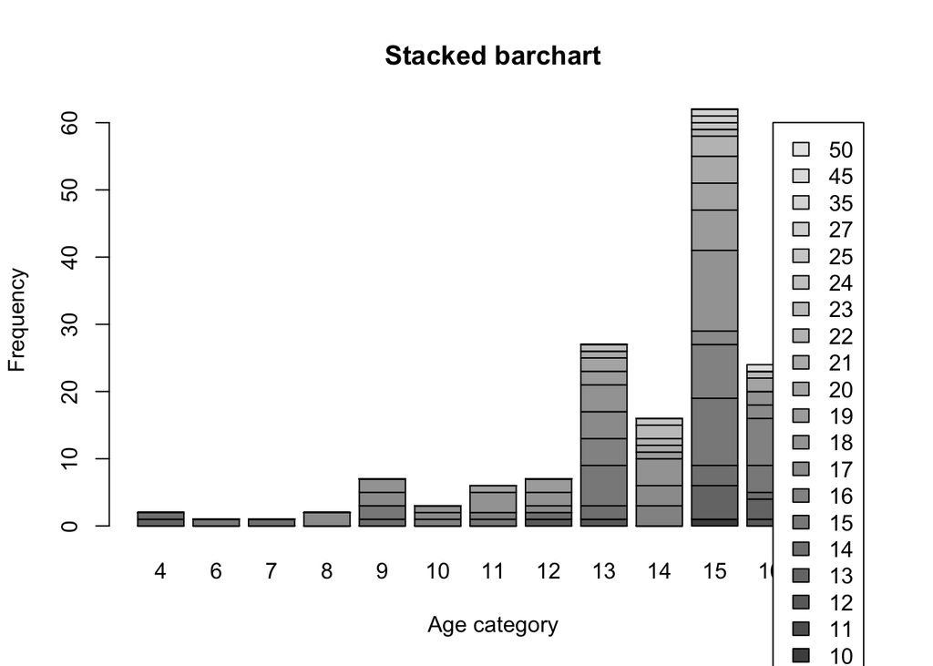

```r
tab.agecigage <- table(dat$cigage,dat$age2)
barplot(tab.agecigage,
        main = "Stacked barchart",
        xlab = "Age category", ylab = "Frequency",
        legend.text = rownames(tab.agecigage),
        beside = FALSE) # Stacked bars (default)
```

Earliest age range is 10.

```r
table(dat$iralcage,dat$age2)
```

```
##
##       4  6  7  8  9 10 11 12 13 14 15 16 17
##   5   0  0  0  0  0  0  0  0  1  0  0  1  0
##   7   0  0  0  0  0  0  0  0  0  0  0  1  0
##   8   0  0  0  0  0  0  0  0  0  0  2  0  0
##   9   0  0  0  0  0  0  0  0  1  0  0  0  0
##   10  0  1  0  0  0  0  0  0  0  0  2  1  0
##   11  1  0  0  1  0  0  0  0  0  0  2  0  0
##   12  0  0  0  0  1  1  0  2  0  1 10  3  1
##   13  1  0  0  0  2  0  0  0  5  1  9  1  2
##   14  0  0  0  0  1  1  1  1  4  2  6  5  1
##   15  0  0  0  0  2  0  1  1  7  1  4  3  0
##   16  0  0  1  1  1  0  0  1  2  6  7  5  2
##   17  0  0  0  0  0  0  0  1  2  0  7  2  0
##   18  0  0  0  0  0  1  1  1  1  3 10  2  4
##   19  0  0  0  0  0  0  1  0  1  0  2  0  2
##   20  0  0  0  0  0  0  1  0  0  0  0  0  1
##   21  0  0  0  0  0  0  1  0  3  2  0  0  0
##   23  0  0  0  0  0  0  0  0  0  0  1  0  0
```

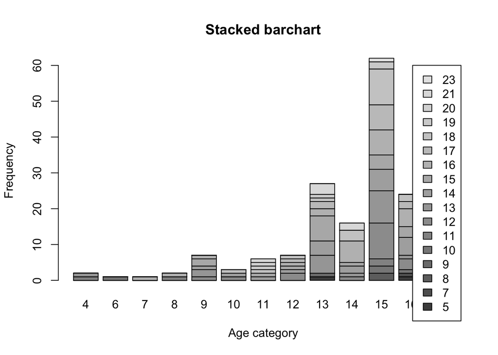

```r
tab.ageiralcage <- table(dat$iralcage,dat$age2)
barplot(tab.ageiralcage,
        main = "Stacked barchart",
        xlab = "Age category", ylab = "Frequency",
        legend.text = rownames(tab.ageiralcage),
        beside = FALSE) # Stacked bars (default)
```

Earliest age range is 5.

## Problem 5: Sexual attraction

What does the distribution of sexual attraction look like? Is this what you expected? What is the distribution of sexual attraction by gender?

```r
table(dat$sexatract,dat$irsex)
```

```
##
##       1  2
##   1  82 54
##   2   3 13
##   3   0  9
##   4   1  2
##   5   2  1
##   6   1  0
##   99  2  1
```

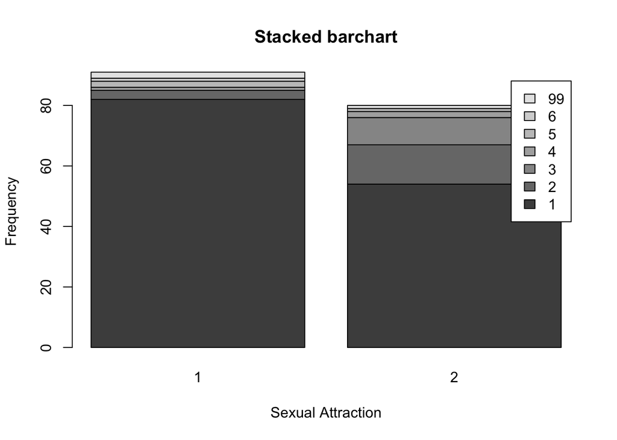

```r
tab.irsexatract <- table(dat$sexatract,dat$irsex)
barplot(tab.irsexatract,
        main = "Stacked barchart",
        xlab = "Sexual Attraction", ylab = "Frequency",
        legend.text = rownames(tab.irsexatract),
        beside = FALSE) # Stacked bars (default)
```

Answer: “I am only attracted to the oppisote sex” accounts for the majority of both males and females, however it accounts for nearly all men. From there, the numbers are very low. More women state they are as equally attracted to men as they are to other women. The difference is very minimal for those who selected “I am mostly attracted to same sex,” “I am only attracted to same sex,” I am not sure," and those who skipped the question. I am not surprised. There’s a great deal of non-binary, intersex, transgender, and other sexual identities outside of male and female that aren’t accounted for. Furthermore, these individuals left out would most likely not be in the first category, thus varying the data and evening out the distribution of the data.

## Problem 6: English speaking

What does the distribution of English speaking look like in the sample? Is this what you might expect for a random sample of the US population?

```r
table(dat$speakengl,dat$irsex)
```

```
##
##      1  2
##   1 84 77
##   2  7  1
##   3  0  2
```

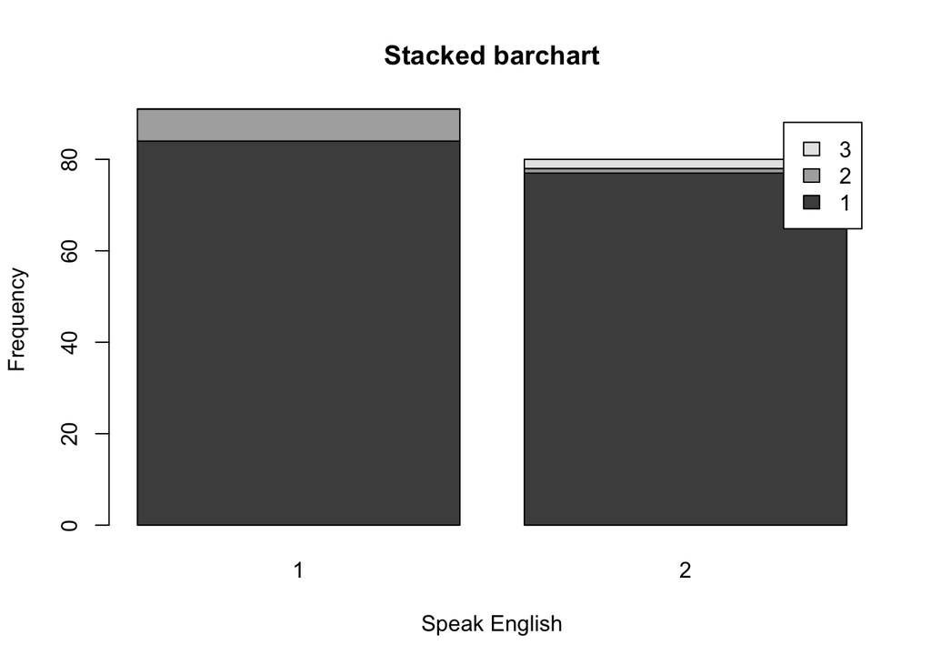

```r
tab.irsexspeakengl <- table(dat$speakengl,dat$irsex)
barplot(tab.irsexspeakengl,
        main = "Stacked barchart",
        xlab = "Speak English", ylab = "Frequency",
        legend.text = rownames(tab.irsexspeakengl),
        beside = FALSE) # Stacked bars (default)
```

Answer: There is an extremely high frequency of individuals that can speak english very well. It accounts for nearly all men and women respectively. A small group of individuals stated they spoke english well (7 men and 1 woman) and 2 women stated they spoke english not well.

Are there more English speaker females or males?

Answer: There are more male English speakers.